# R Exercises CO2 emission

Download data files

I recently saw this graph I thought it would be a good exercise to try and reproduce a similar graph from online-available data (graph source: [J.-M. Jancovici](https://www.facebook.com/jeanmarc.jancovici/photos/a.153593767280/10158534453647281/?type=3)):

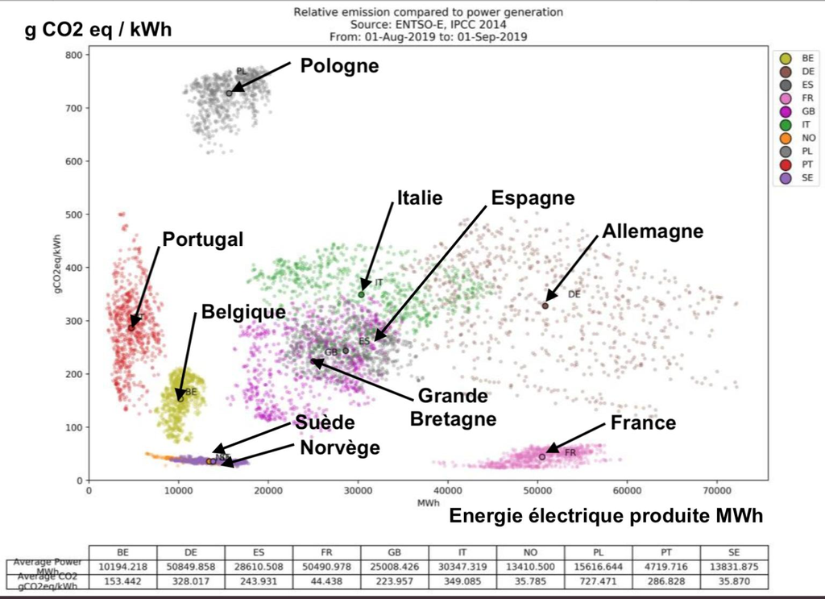

Of course, it would be too easy if we could find the actual data in the correct format…

Here, we will try reproducing the following graphs from CO2_emission.csv, energy-use-per-capita.csv, country-and-continent.csv and tot_population.csv (sources: [CO2](https://databank.worldbank.org/reports.aspx?source=2&series=EN.ATM.CO2E.PC&country=#), [Energy](https://ourworldindata.org/energy-production-and-changing-energy-sources#per-capita-electricity-consumption), [Population](https://github.com/datasets/population/blob/master/data/population.csv), [countries and continents](https://datahub.io/JohnSnowLabs/country-and-continent-codes-list)).

You can get help on dataset merging [here](https://rpubs.com/bradleyboehmke/data_wrangling).

# Data wrangling

- Load the different datasets in tibbles named `CO2`, `continent`, `pop` and `energy`
  - In the case of `continent`, we care only about the 1st and 5th columns, respectively “Continent”, and “Code”
- Make sure all tibbles are tidy, and that the column types (double, character…) are set correctly.
- Merge all tibbles into a single one using `inner_join`
- We are only interested in the columns ‘Code’, ‘Year’, ‘CO2’, ‘Continent’, ‘Energy’, ‘Country’ and ‘Population’. This tibble should look like the tibble printed below
- Create a vector of the countries you are interested in (e.g. EU…)
- Create a tibble `ave` containing the averaged CO2 emission, Energy consumption and Population for each country of this group of countries

```
# A tibble: 5,990 × 7
   Code   Year   CO2 Continent Energy Country Population
   <chr> <dbl> <dbl> <chr>      <dbl> <chr>        <dbl>
 1 ALB    1971  1.99 Europe     9131. Albania    2187853
 2 ALB    1972  2.52 Europe    10067. Albania    2243126
 3 ALB    1973  2.30 Europe     8870. Albania    2296752
 4 ALB    1974  1.85 Europe     9036. Albania    2350124
 5 ALB    1975  1.91 Europe     9617. Albania    2404831
 6 ALB    1976  2.01 Europe    10362. Albania    2458526
 7 ALB    1977  2.28 Europe    10743. Albania    2513546
 8 ALB    1978  2.53 Europe    11756. Albania    2566266
 9 ALB    1979  2.90 Europe    10051. Albania    2617832
10 ALB    1980  1.94 Europe    13369. Albania    2671997
# ℹ 5,980 more rows
```

# Plotting

- Try reproducing the following plots. The following graphs are for countries within the EU (as of 2019). Make it for the continent of your origin.
  - Don’t bother with the text labels first
  - Try adding them using the library `ggrepel`

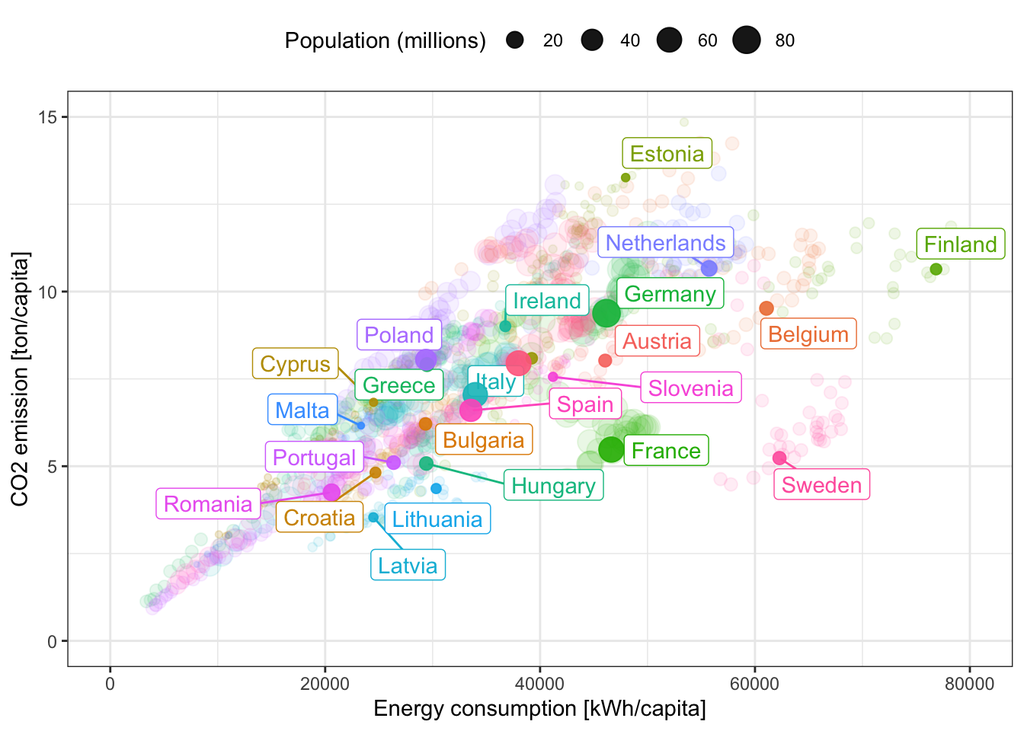

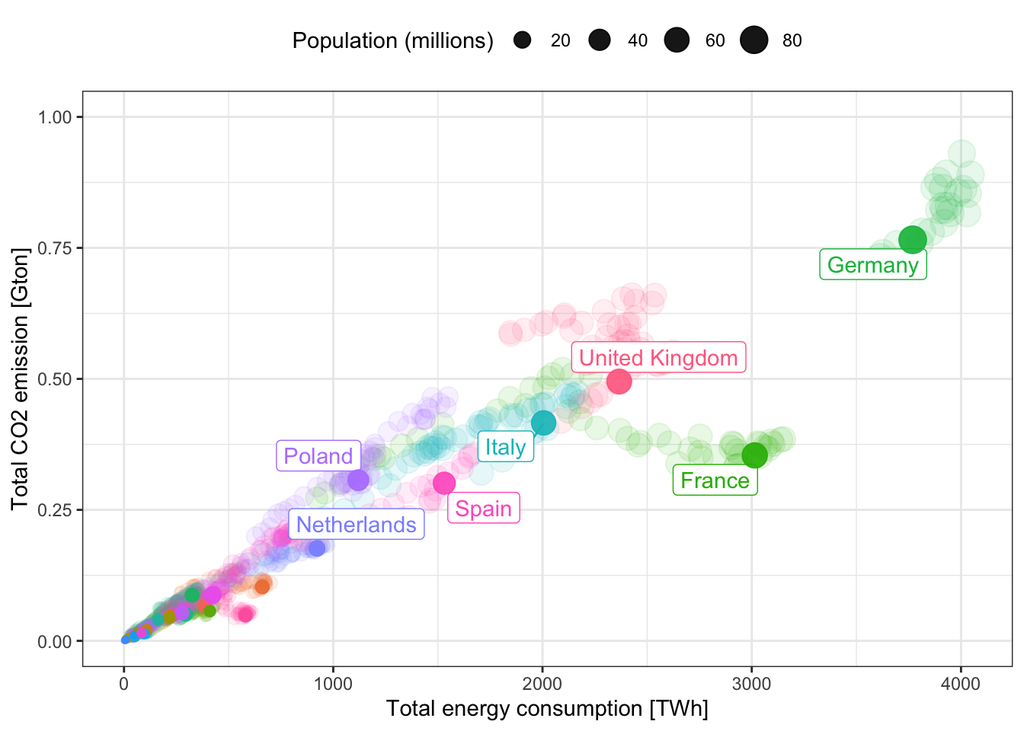